# Risk Factor Analysis

## Outcome Variable

**Outcome Variable:** ever_wasted

## Predictor Variables

**Intervention Variable:** birthlen

**Adjustment Set:**

- arm
- sex
- W_mage
- meducyrs
- feducyrs
- vagbrth
- single
- brthmon
- W_parity
- delta_W_mage
- delta_meducyrs
- delta_feducyrs
- delta_vagbrth
- delta_single
- delta_brthmon
- delta_W_parity

## Stratifying Variables

The analysis was stratified on these variable(s):

- agecat
- studyid
- country

## Data Summary

| agecat | studyid | country | birthlen | ever_wasted | n_cell | n |
| --- | --- | --- | --- | --- | --- | --- |
| 0-24 months (no birth wast) | CMC-V-BCS-2002 | INDIA | >=50 cm | 0 | 11 | 104 |
| 0-24 months (no birth wast) | CMC-V-BCS-2002 | INDIA | >=50 cm | 1 | 5 | 104 |
| 0-24 months (no birth wast) | CMC-V-BCS-2002 | INDIA | <48 cm | 0 | 22 | 104 |
| 0-24 months (no birth wast) | CMC-V-BCS-2002 | INDIA | <48 cm | 1 | 26 | 104 |
| 0-24 months (no birth wast) | CMC-V-BCS-2002 | INDIA | [48-50) cm | 0 | 18 | 104 |
| 0-24 months (no birth wast) | CMC-V-BCS-2002 | INDIA | [48-50) cm | 1 | 22 | 104 |
| 0-24 months (no birth wast) | CMIN | BANGLADESH | >=50 cm | 0 | 1 | 17 |
| 0-24 months (no birth wast) | CMIN | BANGLADESH | >=50 cm | 1 | 0 | 17 |
| 0-24 months (no birth wast) | CMIN | BANGLADESH | <48 cm | 0 | 7 | 17 |
| 0-24 months (no birth wast) | CMIN | BANGLADESH | <48 cm | 1 | 4 | 17 |
| 0-24 months (no birth wast) | CMIN | BANGLADESH | [48-50) cm | 0 | 4 | 17 |
| 0-24 months (no birth wast) | CMIN | BANGLADESH | [48-50) cm | 1 | 1 | 17 |
| 0-24 months (no birth wast) | COHORTS | GUATEMALA | >=50 cm | 0 | 382 | 821 |
| 0-24 months (no birth wast) | COHORTS | GUATEMALA | >=50 cm | 1 | 38 | 821 |
| 0-24 months (no birth wast) | COHORTS | GUATEMALA | <48 cm | 0 | 130 | 821 |
| 0-24 months (no birth wast) | COHORTS | GUATEMALA | <48 cm | 1 | 25 | 821 |
| 0-24 months (no birth wast) | COHORTS | GUATEMALA | [48-50) cm | 0 | 219 | 821 |
| 0-24 months (no birth wast) | COHORTS | GUATEMALA | [48-50) cm | 1 | 27 | 821 |
| 0-24 months (no birth wast) | COHORTS | INDIA | >=50 cm | 0 | 1185 | 6400 |
| 0-24 months (no birth wast) | COHORTS | INDIA | >=50 cm | 1 | 204 | 6400 |
| 0-24 months (no birth wast) | COHORTS | INDIA | <48 cm | 0 | 2044 | 6400 |
| 0-24 months (no birth wast) | COHORTS | INDIA | <48 cm | 1 | 600 | 6400 |
| 0-24 months (no birth wast) | COHORTS | INDIA | [48-50) cm | 0 | 1924 | 6400 |
| 0-24 months (no birth wast) | COHORTS | INDIA | [48-50) cm | 1 | 443 | 6400 |
| 0-24 months (no birth wast) | COHORTS | PHILIPPINES | >=50 cm | 0 | 848 | 3011 |
| 0-24 months (no birth wast) | COHORTS | PHILIPPINES | >=50 cm | 1 | 273 | 3011 |
| 0-24 months (no birth wast) | COHORTS | PHILIPPINES | <48 cm | 0 | 454 | 3011 |
| 0-24 months (no birth wast) | COHORTS | PHILIPPINES | <48 cm | 1 | 286 | 3011 |
| 0-24 months (no birth wast) | COHORTS | PHILIPPINES | [48-50) cm | 0 | 795 | 3011 |
| 0-24 months (no birth wast) | COHORTS | PHILIPPINES | [48-50) cm | 1 | 355 | 3011 |

[output cut: 282 more lines]

The following strata were considered:

- agecat: 0-24 months (no birth wast), studyid: CMC-V-BCS-2002, country: INDIA
- agecat: 0-24 months (no birth wast), studyid: CMIN, country: BANGLADESH
- agecat: 0-24 months (no birth wast), studyid: COHORTS, country: GUATEMALA
- agecat: 0-24 months (no birth wast), studyid: COHORTS, country: INDIA
- agecat: 0-24 months (no birth wast), studyid: COHORTS, country: PHILIPPINES
- agecat: 0-24 months (no birth wast), studyid: CONTENT, country: PERU
- agecat: 0-24 months (no birth wast), studyid: EE, country: PAKISTAN
- agecat: 0-24 months (no birth wast), studyid: GMS-Nepal, country: NEPAL
- agecat: 0-24 months (no birth wast), studyid: IRC, country: INDIA
- agecat: 0-24 months (no birth wast), studyid: JiVitA-3, country: BANGLADESH
- agecat: 0-24 months (no birth wast), studyid: JiVitA-4, country: BANGLADESH
- agecat: 0-24 months (no birth wast), studyid: Keneba, country: GAMBIA
- agecat: 0-24 months (no birth wast), studyid: MAL-ED, country: BANGLADESH
- agecat: 0-24 months (no birth wast), studyid: MAL-ED, country: BRAZIL
- agecat: 0-24 months (no birth wast), studyid: MAL-ED, country: INDIA
- agecat: 0-24 months (no birth wast), studyid: MAL-ED, country: NEPAL
- agecat: 0-24 months (no birth wast), studyid: MAL-ED, country: PERU
- agecat: 0-24 months (no birth wast), studyid: MAL-ED, country: SOUTH AFRICA
- agecat: 0-24 months (no birth wast), studyid: MAL-ED, country: TANZANIA, UNITED REPUBLIC OF
- agecat: 0-24 months (no birth wast), studyid: NIH-Birth, country: BANGLADESH
- agecat: 0-24 months (no birth wast), studyid: NIH-Crypto, country: BANGLADESH
- agecat: 0-24 months (no birth wast), studyid: PROBIT, country: BELARUS
- agecat: 0-24 months (no birth wast), studyid: PROVIDE, country: BANGLADESH
- agecat: 0-24 months (no birth wast), studyid: ResPak, country: PAKISTAN
- agecat: 0-24 months (no birth wast), studyid: SAS-CompFeed, country: INDIA
- agecat: 0-24 months (no birth wast), studyid: ZVITAMBO, country: ZIMBABWE
- agecat: 0-6 months (no birth wast), studyid: CMC-V-BCS-2002, country: INDIA
- agecat: 0-6 months (no birth wast), studyid: CMIN, country: BANGLADESH
- agecat: 0-6 months (no birth wast), studyid: COHORTS, country: GUATEMALA
- agecat: 0-6 months (no birth wast), studyid: COHORTS, country: INDIA
- agecat: 0-6 months (no birth wast), studyid: COHORTS, country: PHILIPPINES
- agecat: 0-6 months (no birth wast), studyid: CONTENT, country: PERU
- agecat: 0-6 months (no birth wast), studyid: EE, country: PAKISTAN
- agecat: 0-6 months (no birth wast), studyid: GMS-Nepal, country: NEPAL
- agecat: 0-6 months (no birth wast), studyid: IRC, country: INDIA
- agecat: 0-6 months (no birth wast), studyid: JiVitA-3, country: BANGLADESH
- agecat: 0-6 months (no birth wast), studyid: JiVitA-4, country: BANGLADESH
- agecat: 0-6 months (no birth wast), studyid: Keneba, country: GAMBIA
- agecat: 0-6 months (no birth wast), studyid: MAL-ED, country: BANGLADESH
- agecat: 0-6 months (no birth wast), studyid: MAL-ED, country: BRAZIL
- agecat: 0-6 months (no birth wast), studyid: MAL-ED, country: INDIA
- agecat: 0-6 months (no birth wast), studyid: MAL-ED, country: NEPAL
- agecat: 0-6 months (no birth wast), studyid: MAL-ED, country: PERU
- agecat: 0-6 months (no birth wast), studyid: MAL-ED, country: SOUTH AFRICA
- agecat: 0-6 months (no birth wast), studyid: MAL-ED, country: TANZANIA, UNITED REPUBLIC OF
- agecat: 0-6 months (no birth wast), studyid: NIH-Birth, country: BANGLADESH
- agecat: 0-6 months (no birth wast), studyid: NIH-Crypto, country: BANGLADESH
- agecat: 0-6 months (no birth wast), studyid: PROBIT, country: BELARUS
- agecat: 0-6 months (no birth wast), studyid: PROVIDE, country: BANGLADESH
- agecat: 0-6 months (no birth wast), studyid: ResPak, country: PAKISTAN
- agecat: 0-6 months (no birth wast), studyid: SAS-CompFeed, country: INDIA
- agecat: 0-6 months (no birth wast), studyid: ZVITAMBO, country: ZIMBABWE

### Dropped Strata

Some strata were dropped due to rare outcomes:

- agecat: 0-24 months (no birth wast), studyid: CMIN, country: BANGLADESH
- agecat: 0-24 months (no birth wast), studyid: CONTENT, country: PERU
- agecat: 0-24 months (no birth wast), studyid: MAL-ED, country: BRAZIL
- agecat: 0-24 months (no birth wast), studyid: MAL-ED, country: INDIA
- agecat: 0-24 months (no birth wast), studyid: MAL-ED, country: NEPAL
- agecat: 0-24 months (no birth wast), studyid: MAL-ED, country: PERU
- agecat: 0-24 months (no birth wast), studyid: MAL-ED, country: SOUTH AFRICA
- agecat: 0-24 months (no birth wast), studyid: MAL-ED, country: TANZANIA, UNITED REPUBLIC OF
- agecat: 0-24 months (no birth wast), studyid: ResPak, country: PAKISTAN
- agecat: 0-6 months (no birth wast), studyid: CMIN, country: BANGLADESH
- agecat: 0-6 months (no birth wast), studyid: CONTENT, country: PERU
- agecat: 0-6 months (no birth wast), studyid: MAL-ED, country: BANGLADESH
- agecat: 0-6 months (no birth wast), studyid: MAL-ED, country: BRAZIL
- agecat: 0-6 months (no birth wast), studyid: MAL-ED, country: INDIA
- agecat: 0-6 months (no birth wast), studyid: MAL-ED, country: NEPAL
- agecat: 0-6 months (no birth wast), studyid: MAL-ED, country: PERU
- agecat: 0-6 months (no birth wast), studyid: MAL-ED, country: SOUTH AFRICA
- agecat: 0-6 months (no birth wast), studyid: MAL-ED, country: TANZANIA, UNITED REPUBLIC OF
- agecat: 0-6 months (no birth wast), studyid: ResPak, country: PAKISTAN

## Methods Detail

We're interested in the causal parameters $E[Y_a]$ for all values of $a \in \mathcal{A}$. These parameters represent the mean outcome if, possibly contrary to fact, we intervened to set all units to have $A=a$. Under the randomization and positivity assumptions, these are identified by the statistical parameters $\psi_a=E_W[E_{Y|A,W}(Y|A=a,W)]$. In addition, we're interested in the mean of $Y$, $E[Y]$ under no intervention (the observed mean). We will estimate these parameters by using SuperLearner to fit the relevant likelihood factors -- $E_{Y|A,W}(Y|A=a,W)$ and $p(A=a|W)$, and then updating our likelihood fit using a joint TMLE.

For unadjusted analyses ($W=\{\}$), initial likelihoods were estimated using Lrnr_glm to estimate the simple $E(Y|A)$ and Lrnr_mean to estimate $p(A)$. For adjusted analyses, a small library containing Lrnr_glmnet, Lrnr_xgboost, and Lrnr_mean was used.

Having estimated these parameters, we will then use the delta method to estimate relative risks and attributable risks relative to a prespecified baseline level of $A$.

# Results Detail

## Results Plots

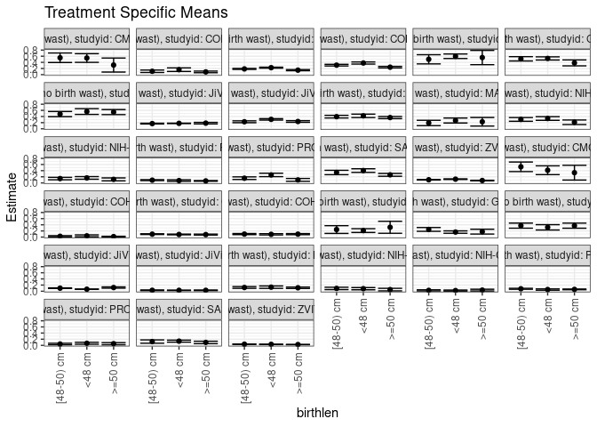

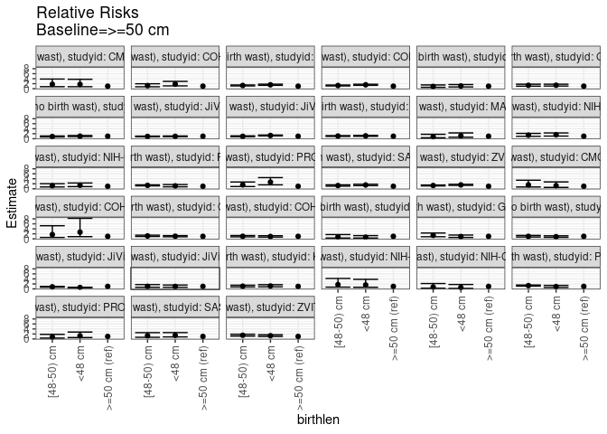

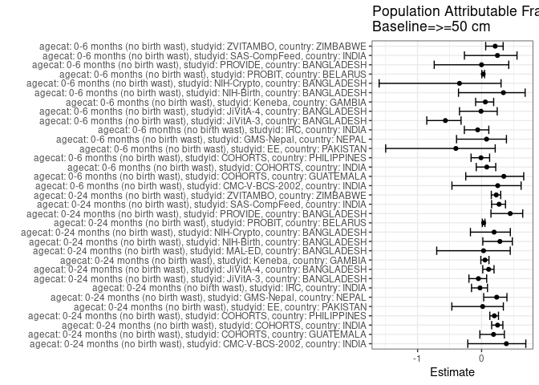

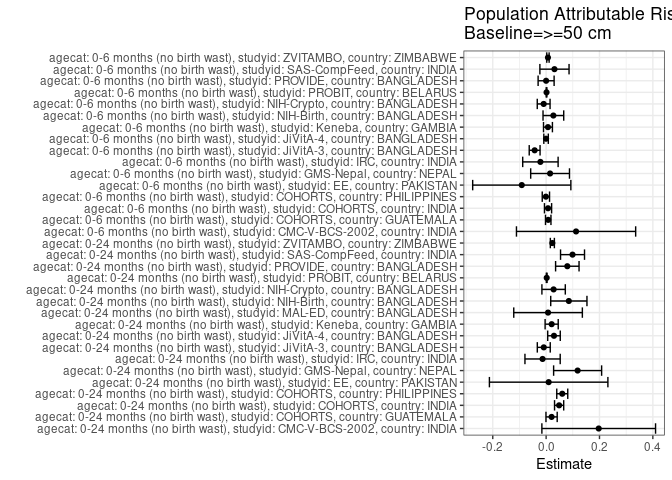

## Results Table

### Parameter: TSM

| agecat | studyid | country | intervention_level | baseline_level | estimate | ci_lower | ci_upper |
| --- | --- | --- | --- | --- | --- | --- | --- |
| 0-24 months (no birth wast) | CMC-V-BCS-2002 | INDIA | >=50 cm | NA | 0.3125000 | 0.0842832 | 0.5407168 |
| 0-24 months (no birth wast) | CMC-V-BCS-2002 | INDIA | <48 cm | NA | 0.5416667 | 0.4000278 | 0.6833055 |
| 0-24 months (no birth wast) | CMC-V-BCS-2002 | INDIA | [48-50) cm | NA | 0.5500000 | 0.3950813 | 0.7049187 |
| 0-24 months (no birth wast) | COHORTS | GUATEMALA | >=50 cm | NA | 0.0891646 | 0.0616080 | 0.1167213 |
| 0-24 months (no birth wast) | COHORTS | GUATEMALA | <48 cm | NA | 0.1622058 | 0.1035770 | 0.2208345 |
| 0-24 months (no birth wast) | COHORTS | GUATEMALA | [48-50) cm | NA | 0.1095656 | 0.0704268 | 0.1487043 |
| 0-24 months (no birth wast) | COHORTS | INDIA | >=50 cm | NA | 0.1461272 | 0.1274475 | 0.1648069 |
| 0-24 months (no birth wast) | COHORTS | INDIA | <48 cm | NA | 0.2267205 | 0.2107091 | 0.2427320 |
| 0-24 months (no birth wast) | COHORTS | INDIA | [48-50) cm | NA | 0.1869996 | 0.1711902 | 0.2028090 |
| 0-24 months (no birth wast) | COHORTS | PHILIPPINES | >=50 cm | NA | 0.2431071 | 0.2181765 | 0.2680377 |
| 0-24 months (no birth wast) | COHORTS | PHILIPPINES | <48 cm | NA | 0.3788562 | 0.3440309 | 0.4136814 |
| 0-24 months (no birth wast) | COHORTS | PHILIPPINES | [48-50) cm | NA | 0.3094575 | 0.2826978 | 0.3362172 |
| 0-24 months (no birth wast) | EE | PAKISTAN | >=50 cm | NA | 0.5572085 | 0.3249810 | 0.7894361 |
| 0-24 months (no birth wast) | EE | PAKISTAN | <48 cm | NA | 0.5988899 | 0.5255405 | 0.6722394 |
| 0-24 months (no birth wast) | EE | PAKISTAN | [48-50) cm | NA | 0.4995278 | 0.3501733 | 0.6488824 |
| 0-24 months (no birth wast) | GMS-Nepal | NEPAL | >=50 cm | NA | 0.3826976 | 0.2859659 | 0.4794294 |
| 0-24 months (no birth wast) | GMS-Nepal | NEPAL | <48 cm | NA | 0.5279714 | 0.4761711 | 0.5797718 |
| 0-24 months (no birth wast) | GMS-Nepal | NEPAL | [48-50) cm | NA | 0.5153212 | 0.4454935 | 0.5851489 |
| 0-24 months (no birth wast) | IRC | INDIA | >=50 cm | NA | 0.5440610 | 0.4615570 | 0.6265650 |
| 0-24 months (no birth wast) | IRC | INDIA | <48 cm | NA | 0.5614336 | 0.4681194 | 0.6547478 |
| 0-24 months (no birth wast) | IRC | INDIA | [48-50) cm | NA | 0.4790873 | 0.3948300 | 0.5633445 |
| 0-24 months (no birth wast) | JiVitA-3 | BANGLADESH | >=50 cm | NA | 0.1845133 | 0.1597973 | 0.2092292 |
| 0-24 months (no birth wast) | JiVitA-3 | BANGLADESH | <48 cm | NA | 0.1773890 | 0.1705949 | 0.1841832 |
| 0-24 months (no birth wast) | JiVitA-3 | BANGLADESH | [48-50) cm | NA | 0.1692245 | 0.1564398 | 0.1820093 |
| 0-24 months (no birth wast) | JiVitA-4 | BANGLADESH | >=50 cm | NA | 0.2369052 | 0.2102762 | 0.2635343 |
| 0-24 months (no birth wast) | JiVitA-4 | BANGLADESH | <48 cm | NA | 0.3068262 | 0.2831292 | 0.3305231 |
| 0-24 months (no birth wast) | JiVitA-4 | BANGLADESH | [48-50) cm | NA | 0.2287394 | 0.1980177 | 0.2594611 |
| 0-24 months (no birth wast) | Keneba | GAMBIA | >=50 cm | NA | 0.3657862 | 0.3315644 | 0.4000080 |
| 0-24 months (no birth wast) | Keneba | GAMBIA | <48 cm | NA | 0.4213660 | 0.3650741 | 0.4776579 |
| 0-24 months (no birth wast) | Keneba | GAMBIA | [48-50) cm | NA | 0.3947335 | 0.3512426 | 0.4382244 |

[output cut: 69 more lines]

### Parameter: E(Y)

| agecat | studyid | country | intervention_level | baseline_level | estimate | ci_lower | ci_upper |
| --- | --- | --- | --- | --- | --- | --- | --- |
| 0-24 months (no birth wast) | CMC-V-BCS-2002 | INDIA | NA | NA | 0.5096154 | 0.4130727 | 0.6061580 |
| 0-24 months (no birth wast) | COHORTS | GUATEMALA | NA | NA | 0.1096224 | 0.0882390 | 0.1310059 |
| 0-24 months (no birth wast) | COHORTS | INDIA | NA | NA | 0.1948438 | 0.1851392 | 0.2045483 |
| 0-24 months (no birth wast) | COHORTS | PHILIPPINES | NA | NA | 0.3035536 | 0.2871278 | 0.3199794 |
| 0-24 months (no birth wast) | EE | PAKISTAN | NA | NA | 0.5666667 | 0.5038429 | 0.6294904 |
| 0-24 months (no birth wast) | GMS-Nepal | NEPAL | NA | NA | 0.5007587 | 0.4625551 | 0.5389624 |
| 0-24 months (no birth wast) | IRC | INDIA | NA | NA | 0.5307692 | 0.4811763 | 0.5803621 |
| 0-24 months (no birth wast) | JiVitA-3 | BANGLADESH | NA | NA | 0.1757133 | 0.1696451 | 0.1817815 |
| 0-24 months (no birth wast) | JiVitA-4 | BANGLADESH | NA | NA | 0.2663530 | 0.2512746 | 0.2814315 |
| 0-24 months (no birth wast) | Keneba | GAMBIA | NA | NA | 0.3865546 | 0.3622809 | 0.4108284 |
| 0-24 months (no birth wast) | MAL-ED | BANGLADESH | NA | NA | 0.2358079 | 0.1807067 | 0.2909091 |
| 0-24 months (no birth wast) | NIH-Birth | BANGLADESH | NA | NA | 0.2977625 | 0.2605481 | 0.3349769 |
| 0-24 months (no birth wast) | NIH-Crypto | BANGLADESH | NA | NA | 0.1432361 | 0.1182149 | 0.1682572 |
| 0-24 months (no birth wast) | PROBIT | BELARUS | NA | NA | 0.0680135 | 0.0562135 | 0.0798135 |
| 0-24 months (no birth wast) | PROVIDE | BANGLADESH | NA | NA | 0.1775837 | 0.1489858 | 0.2061816 |
| 0-24 months (no birth wast) | SAS-CompFeed | INDIA | NA | NA | 0.3626595 | 0.3120201 | 0.4132989 |
| 0-24 months (no birth wast) | ZVITAMBO | ZIMBABWE | NA | NA | 0.1019924 | 0.0968873 | 0.1070976 |
| 0-6 months (no birth wast) | CMC-V-BCS-2002 | INDIA | NA | NA | 0.4455446 | 0.3481293 | 0.5429598 |
| 0-6 months (no birth wast) | COHORTS | GUATEMALA | NA | NA | 0.0226986 | 0.0123257 | 0.0330715 |
| 0-6 months (no birth wast) | COHORTS | INDIA | NA | NA | 0.0882353 | 0.0810887 | 0.0953819 |
| 0-6 months (no birth wast) | COHORTS | PHILIPPINES | NA | NA | 0.0946488 | 0.0841546 | 0.1051431 |
| 0-6 months (no birth wast) | EE | PAKISTAN | NA | NA | 0.2268908 | 0.1735692 | 0.2802123 |
| 0-6 months (no birth wast) | GMS-Nepal | NEPAL | NA | NA | 0.1918877 | 0.1613794 | 0.2223959 |
| 0-6 months (no birth wast) | IRC | INDIA | NA | NA | 0.3494624 | 0.3009450 | 0.3979798 |
| 0-6 months (no birth wast) | JiVitA-3 | BANGLADESH | NA | NA | 0.0760414 | 0.0718411 | 0.0802418 |
| 0-6 months (no birth wast) | JiVitA-4 | BANGLADESH | NA | NA | 0.0289057 | 0.0236101 | 0.0342013 |
| 0-6 months (no birth wast) | Keneba | GAMBIA | NA | NA | 0.1187215 | 0.1025243 | 0.1349187 |
| 0-6 months (no birth wast) | NIH-Birth | BANGLADESH | NA | NA | 0.0797872 | 0.0574049 | 0.1021695 |
| 0-6 months (no birth wast) | NIH-Crypto | BANGLADESH | NA | NA | 0.0267023 | 0.0151493 | 0.0382553 |
| 0-6 months (no birth wast) | PROBIT | BELARUS | NA | NA | 0.0612233 | 0.0502388 | 0.0722078 |
| 0-6 months (no birth wast) | PROVIDE | BANGLADESH | NA | NA | 0.0541728 | 0.0371844 | 0.0711612 |
| 0-6 months (no birth wast) | SAS-CompFeed | INDIA | NA | NA | 0.1264525 | 0.0961151 | 0.1567899 |
| 0-6 months (no birth wast) | ZVITAMBO | ZIMBABWE | NA | NA | 0.0322167 | 0.0292105 | 0.0352229 |

### Parameter: RR

| agecat | studyid | country | intervention_level | baseline_level | estimate | ci_lower | ci_upper |
| --- | --- | --- | --- | --- | --- | --- | --- |
| 0-24 months (no birth wast) | CMC-V-BCS-2002 | INDIA | >=50 cm | >=50 cm | 1.0000000 | 1.0000000 | 1.000000 |
| 0-24 months (no birth wast) | CMC-V-BCS-2002 | INDIA | <48 cm | >=50 cm | 1.7333333 | 0.7979976 | 3.764979 |
| 0-24 months (no birth wast) | CMC-V-BCS-2002 | INDIA | [48-50) cm | >=50 cm | 1.7600000 | 0.8045947 | 3.849889 |
| 0-24 months (no birth wast) | COHORTS | GUATEMALA | >=50 cm | >=50 cm | 1.0000000 | 1.0000000 | 1.000000 |
| 0-24 months (no birth wast) | COHORTS | GUATEMALA | <48 cm | >=50 cm | 1.8191716 | 1.1310654 | 2.925901 |
| 0-24 months (no birth wast) | COHORTS | GUATEMALA | [48-50) cm | >=50 cm | 1.2288006 | 0.7662676 | 1.970527 |
| 0-24 months (no birth wast) | COHORTS | INDIA | >=50 cm | >=50 cm | 1.0000000 | 1.0000000 | 1.000000 |
| 0-24 months (no birth wast) | COHORTS | INDIA | <48 cm | >=50 cm | 1.5515287 | 1.3410567 | 1.795033 |
| 0-24 months (no birth wast) | COHORTS | INDIA | [48-50) cm | >=50 cm | 1.2797045 | 1.0981203 | 1.491316 |
| 0-24 months (no birth wast) | COHORTS | PHILIPPINES | >=50 cm | >=50 cm | 1.0000000 | 1.0000000 | 1.000000 |
| 0-24 months (no birth wast) | COHORTS | PHILIPPINES | <48 cm | >=50 cm | 1.5583918 | 1.3584286 | 1.787790 |
| 0-24 months (no birth wast) | COHORTS | PHILIPPINES | [48-50) cm | >=50 cm | 1.2729263 | 1.1136154 | 1.455028 |
| 0-24 months (no birth wast) | EE | PAKISTAN | >=50 cm | >=50 cm | 1.0000000 | 1.0000000 | 1.000000 |
| 0-24 months (no birth wast) | EE | PAKISTAN | <48 cm | >=50 cm | 1.0748040 | 0.6963470 | 1.658948 |
| 0-24 months (no birth wast) | EE | PAKISTAN | [48-50) cm | >=50 cm | 0.8964827 | 0.5347897 | 1.502799 |
| 0-24 months (no birth wast) | GMS-Nepal | NEPAL | >=50 cm | >=50 cm | 1.0000000 | 1.0000000 | 1.000000 |
| 0-24 months (no birth wast) | GMS-Nepal | NEPAL | <48 cm | >=50 cm | 1.3796045 | 1.0515057 | 1.810079 |
| 0-24 months (no birth wast) | GMS-Nepal | NEPAL | [48-50) cm | >=50 cm | 1.3465492 | 1.0112484 | 1.793026 |
| 0-24 months (no birth wast) | IRC | INDIA | >=50 cm | >=50 cm | 1.0000000 | 1.0000000 | 1.000000 |
| 0-24 months (no birth wast) | IRC | INDIA | <48 cm | >=50 cm | 1.0319313 | 0.8239534 | 1.292406 |
| 0-24 months (no birth wast) | IRC | INDIA | [48-50) cm | >=50 cm | 0.8805764 | 0.6978415 | 1.111162 |
| 0-24 months (no birth wast) | JiVitA-3 | BANGLADESH | >=50 cm | >=50 cm | 1.0000000 | 1.0000000 | 1.000000 |
| 0-24 months (no birth wast) | JiVitA-3 | BANGLADESH | <48 cm | >=50 cm | 0.9613890 | 0.8362463 | 1.105259 |
| 0-24 months (no birth wast) | JiVitA-3 | BANGLADESH | [48-50) cm | >=50 cm | 0.9171402 | 0.7869228 | 1.068905 |
| 0-24 months (no birth wast) | JiVitA-4 | BANGLADESH | >=50 cm | >=50 cm | 1.0000000 | 1.0000000 | 1.000000 |
| 0-24 months (no birth wast) | JiVitA-4 | BANGLADESH | <48 cm | >=50 cm | 1.2951431 | 1.1317841 | 1.482081 |
| 0-24 months (no birth wast) | JiVitA-4 | BANGLADESH | [48-50) cm | >=50 cm | 0.9655312 | 0.8106758 | 1.149967 |
| 0-24 months (no birth wast) | Keneba | GAMBIA | >=50 cm | >=50 cm | 1.0000000 | 1.0000000 | 1.000000 |
| 0-24 months (no birth wast) | Keneba | GAMBIA | <48 cm | >=50 cm | 1.1519461 | 0.9792576 | 1.355088 |
| 0-24 months (no birth wast) | Keneba | GAMBIA | [48-50) cm | >=50 cm | 1.0791371 | 0.9342315 | 1.246519 |

[output cut: 69 more lines]

### Parameter: PAR

| agecat | studyid | country | intervention_level | baseline_level | estimate | ci_lower | ci_upper |
| --- | --- | --- | --- | --- | --- | --- | --- |
| 0-24 months (no birth wast) | CMC-V-BCS-2002 | INDIA | >=50 cm | NA | 0.1971154 | -0.0159054 | 0.4101362 |
| 0-24 months (no birth wast) | COHORTS | GUATEMALA | >=50 cm | NA | 0.0204578 | -0.0005616 | 0.0414771 |
| 0-24 months (no birth wast) | COHORTS | INDIA | >=50 cm | NA | 0.0487165 | 0.0315692 | 0.0658639 |
| 0-24 months (no birth wast) | COHORTS | PHILIPPINES | >=50 cm | NA | 0.0604465 | 0.0398465 | 0.0810465 |
| 0-24 months (no birth wast) | EE | PAKISTAN | >=50 cm | NA | 0.0094581 | -0.2125824 | 0.2314987 |
| 0-24 months (no birth wast) | GMS-Nepal | NEPAL | >=50 cm | NA | 0.1180611 | 0.0281004 | 0.2080218 |
| 0-24 months (no birth wast) | IRC | INDIA | >=50 cm | NA | -0.0132918 | -0.0793554 | 0.0527719 |
| 0-24 months (no birth wast) | JiVitA-3 | BANGLADESH | >=50 cm | NA | -0.0088000 | -0.0330539 | 0.0154540 |
| 0-24 months (no birth wast) | JiVitA-4 | BANGLADESH | >=50 cm | NA | 0.0294478 | 0.0059272 | 0.0529684 |
| 0-24 months (no birth wast) | Keneba | GAMBIA | >=50 cm | NA | 0.0207684 | -0.0038097 | 0.0453465 |
| 0-24 months (no birth wast) | MAL-ED | BANGLADESH | >=50 cm | NA | 0.0072364 | -0.1213413 | 0.1358142 |
| 0-24 months (no birth wast) | NIH-Birth | BANGLADESH | >=50 cm | NA | 0.0851331 | 0.0172294 | 0.1530367 |
| 0-24 months (no birth wast) | NIH-Crypto | BANGLADESH | >=50 cm | NA | 0.0280355 | -0.0158028 | 0.0718738 |
| 0-24 months (no birth wast) | PROBIT | BELARUS | >=50 cm | NA | 0.0021971 | 0.0008465 | 0.0035478 |
| 0-24 months (no birth wast) | PROVIDE | BANGLADESH | >=50 cm | NA | 0.0794490 | 0.0354971 | 0.1234010 |
| 0-24 months (no birth wast) | SAS-CompFeed | INDIA | >=50 cm | NA | 0.0989575 | 0.0540231 | 0.1438920 |
| 0-24 months (no birth wast) | ZVITAMBO | ZIMBABWE | >=50 cm | NA | 0.0233452 | 0.0157803 | 0.0309102 |
| 0-6 months (no birth wast) | CMC-V-BCS-2002 | INDIA | >=50 cm | NA | 0.1122112 | -0.1111633 | 0.3355858 |
| 0-6 months (no birth wast) | COHORTS | GUATEMALA | >=50 cm | NA | 0.0078838 | -0.0023448 | 0.0181124 |
| 0-6 months (no birth wast) | COHORTS | INDIA | >=50 cm | NA | 0.0071637 | -0.0062264 | 0.0205537 |
| 0-6 months (no birth wast) | COHORTS | PHILIPPINES | >=50 cm | NA | -0.0008768 | -0.0145437 | 0.0127901 |
| 0-6 months (no birth wast) | EE | PAKISTAN | >=50 cm | NA | -0.0912911 | -0.2752774 | 0.0926953 |
| 0-6 months (no birth wast) | GMS-Nepal | NEPAL | >=50 cm | NA | 0.0148456 | -0.0578766 | 0.0875678 |
| 0-6 months (no birth wast) | IRC | INDIA | >=50 cm | NA | -0.0214218 | -0.0877734 | 0.0449297 |
| 0-6 months (no birth wast) | JiVitA-3 | BANGLADESH | >=50 cm | NA | -0.0430270 | -0.0633409 | -0.0227130 |
| 0-6 months (no birth wast) | JiVitA-4 | BANGLADESH | >=50 cm | NA | -0.0002456 | -0.0086465 | 0.0081552 |
| 0-6 months (no birth wast) | Keneba | GAMBIA | >=50 cm | NA | 0.0069124 | -0.0097833 | 0.0236082 |
| 0-6 months (no birth wast) | NIH-Birth | BANGLADESH | >=50 cm | NA | 0.0271557 | -0.0116220 | 0.0659333 |
| 0-6 months (no birth wast) | NIH-Crypto | BANGLADESH | >=50 cm | NA | -0.0092259 | -0.0332159 | 0.0147641 |
| 0-6 months (no birth wast) | PROBIT | BELARUS | >=50 cm | NA | 0.0015642 | 0.0002965 | 0.0028319 |
| 0-6 months (no birth wast) | PROVIDE | BANGLADESH | >=50 cm | NA | -0.0000441 | -0.0300327 | 0.0299445 |
| 0-6 months (no birth wast) | SAS-CompFeed | INDIA | >=50 cm | NA | 0.0312693 | -0.0233813 | 0.0859199 |
| 0-6 months (no birth wast) | ZVITAMBO | ZIMBABWE | >=50 cm | NA | 0.0068327 | 0.0024153 | 0.0112501 |

### Parameter: PAF

| agecat | studyid | country | intervention_level | baseline_level | estimate | ci_lower | ci_upper |
| --- | --- | --- | --- | --- | --- | --- | --- |
| 0-24 months (no birth wast) | CMC-V-BCS-2002 | INDIA | >=50 cm | NA | 0.3867925 | -0.2158991 | 0.6907445 |
| 0-24 months (no birth wast) | COHORTS | GUATEMALA | >=50 cm | NA | 0.1866204 | -0.0268096 | 0.3556874 |
| 0-24 months (no birth wast) | COHORTS | INDIA | >=50 cm | NA | 0.2500288 | 0.1573152 | 0.3325419 |
| 0-24 months (no birth wast) | COHORTS | PHILIPPINES | >=50 cm | NA | 0.1991295 | 0.1286368 | 0.2639194 |
| 0-24 months (no birth wast) | EE | PAKISTAN | >=50 cm | NA | 0.0166908 | -0.4647813 | 0.3399036 |
| 0-24 months (no birth wast) | GMS-Nepal | NEPAL | >=50 cm | NA | 0.2357644 | 0.0327523 | 0.3961670 |
| 0-24 months (no birth wast) | IRC | INDIA | >=50 cm | NA | -0.0250425 | -0.1574141 | 0.0921900 |
| 0-24 months (no birth wast) | JiVitA-3 | BANGLADESH | >=50 cm | NA | -0.0500814 | -0.1977031 | 0.0793454 |
| 0-24 months (no birth wast) | JiVitA-4 | BANGLADESH | >=50 cm | NA | 0.1105594 | 0.0181734 | 0.1942522 |
| 0-24 months (no birth wast) | Keneba | GAMBIA | >=50 cm | NA | 0.0537270 | -0.0120689 | 0.1152454 |
| 0-24 months (no birth wast) | MAL-ED | BANGLADESH | >=50 cm | NA | 0.0306878 | -0.7012096 | 0.4477070 |
| 0-24 months (no birth wast) | NIH-Birth | BANGLADESH | >=50 cm | NA | 0.2859094 | 0.0190494 | 0.4801722 |
| 0-24 months (no birth wast) | NIH-Crypto | BANGLADESH | >=50 cm | NA | 0.1957293 | -0.1743461 | 0.4491816 |
| 0-24 months (no birth wast) | PROBIT | BELARUS | >=50 cm | NA | 0.0323043 | 0.0113857 | 0.0527802 |
| 0-24 months (no birth wast) | PROVIDE | BANGLADESH | >=50 cm | NA | 0.4473893 | 0.1460665 | 0.6423860 |
| 0-24 months (no birth wast) | SAS-CompFeed | INDIA | >=50 cm | NA | 0.2728662 | 0.1560925 | 0.3734816 |
| 0-24 months (no birth wast) | ZVITAMBO | ZIMBABWE | >=50 cm | NA | 0.2288919 | 0.1518590 | 0.2989281 |
| 0-6 months (no birth wast) | CMC-V-BCS-2002 | INDIA | >=50 cm | NA | 0.2518519 | -0.4634357 | 0.6175263 |
| 0-6 months (no birth wast) | COHORTS | GUATEMALA | >=50 cm | NA | 0.3473251 | -0.2471956 | 0.6584461 |
| 0-6 months (no birth wast) | COHORTS | INDIA | >=50 cm | NA | 0.0811883 | -0.0836525 | 0.2209542 |
| 0-6 months (no birth wast) | COHORTS | PHILIPPINES | >=50 cm | NA | -0.0092640 | -0.1644972 | 0.1252760 |
| 0-6 months (no birth wast) | EE | PAKISTAN | >=50 cm | NA | -0.4023569 | -1.4985270 | 0.2128943 |
| 0-6 months (no birth wast) | GMS-Nepal | NEPAL | >=50 cm | NA | 0.0773659 | -0.3912777 | 0.3881496 |
| 0-6 months (no birth wast) | IRC | INDIA | >=50 cm | NA | -0.0612994 | -0.2693084 | 0.1126219 |
| 0-6 months (no birth wast) | JiVitA-3 | BANGLADESH | >=50 cm | NA | -0.5658357 | -0.8563441 | -0.3207905 |
| 0-6 months (no birth wast) | JiVitA-4 | BANGLADESH | >=50 cm | NA | -0.0084981 | -0.3454111 | 0.2440464 |
| 0-6 months (no birth wast) | Keneba | GAMBIA | >=50 cm | NA | 0.0582240 | -0.0933165 | 0.1887601 |
| 0-6 months (no birth wast) | NIH-Birth | BANGLADESH | >=50 cm | NA | 0.3403509 | -0.3607389 | 0.6802201 |
| 0-6 months (no birth wast) | NIH-Crypto | BANGLADESH | >=50 cm | NA | -0.3455090 | -1.6009534 | 0.3039497 |
| 0-6 months (no birth wast) | PROBIT | BELARUS | >=50 cm | NA | 0.0255492 | 0.0039966 | 0.0466355 |
| 0-6 months (no birth wast) | PROVIDE | BANGLADESH | >=50 cm | NA | -0.0008141 | -0.7400909 | 0.4243813 |
| 0-6 months (no birth wast) | SAS-CompFeed | INDIA | >=50 cm | NA | 0.2472812 | -0.2681419 | 0.5532159 |
| 0-6 months (no birth wast) | ZVITAMBO | ZIMBABWE | >=50 cm | NA | 0.2120861 | 0.0640703 | 0.3366933 |